# Data quality diagnosis

Choonghyun Ryu

2025-08-31

## Preface

After you have acquired the data, you should do the following:

- **Diagnose data quality.**
  - **If there is a problem with data quality,**
  - **The data must be corrected or re-acquired.**
- Explore data to understand the data and find scenarios for performing the analysis.
- Derive new variables or perform variable transformations.

The dlookr package makes these steps fast and easy:

- **Performs a data diagnosis or automatically generates a data diagnosis report.**
- Discover data in various ways and automatically generate EDA(exploratory data analysis) reports.
- Impute missing values and outliers, resolve skewed data, and categorize continuous variables into categorical variables. And generates an automated report to support it.

This document introduces **Data Quality Diagnosis** methods provided by the dlookr package. You will learn how to diagnose the quality of `tbl_df` data that inherits from data.frame and `data.frame` with functions provided by dlookr.

dlookr increases synergy with `dplyr`. Particularly in data exploration and data wrangling, it increases the efficiency of the `tidyverse` package group.

## Supported data structures

Data diagnosis supports the following data structures.

- data frame: data.frame class.
- data table: tbl_df class.
- **table of DBMS**: table of the DBMS through tbl_dbi.
  - **Use dplyr as the back-end interface for any DBI-compatible database.**

## Data: nycflights13

To illustrate the primary use of the dlookr package, use the `flights` data from the `nycflights13` package. The `flights` data frame is data about departure and arrival on all flights departing from NYC in 2013.

```r
dim(flights)
[1] 3000   19
flights
# A tibble: 3,000 × 19
   year month   day dep_time sched_dep_time dep_delay arr_time sched_arr_time
  <int> <int> <int>    <int>          <int>     <dbl>    <int>          <int>
1  2013     6    17     1033           1040        -7     1246           1309
2  2013    12    26     1343           1329        14     1658           1624
3  2013     8    26     1258           1218        40     1510           1516
4  2013     8    17     1558           1600        -2     1835           1849
# ℹ 2,996 more rows
# ℹ 11 more variables: arr_delay <dbl>, carrier <chr>, flight <int>,
#   tailnum <chr>, origin <chr>, dest <chr>, air_time <dbl>, distance <dbl>,
#   hour <dbl>, minute <dbl>, time_hour <dttm>
```

## Data diagnosis

dlookr aims to diagnose the data and select variables that can not be used for data analysis or to find the variables that need calibration.:

- `diagnose()` provides basic diagnostic information for variables.
- `diagnose_category()` provides detailed diagnostic information for categorical variables.
- `diagnose_numeric()` provides detailed diagnostic information for numerical variables.
- `diagnose_outlier()` and `plot_outlier()` provide information and visualization of outliers.

### General diagnosis of all variables with `diagnose()`

`diagnose()` allows the diagnosis of variables in a data frame. Like the function of dplyr, the first argument is the tibble (or data frame). The second and subsequent arguments refer to variables within that data frame.

The variables of the `tbl_df` object returned by `diagnose ()` are as follows.

- `variables`: variable names
- `types`: the data type of the variables
- `missing_count`: number of missing values
- `missing_percent`: percentage of missing value
- `unique_count`: number of unique value
- `unique_rate`: rate of unique value. unique_count / number of observation

For example, we can diagnose all variables in `flights`:

```r
diagnose(flights)
# A tibble: 19 × 6
  variables types   missing_count missing_percent unique_count unique_rate
  <chr>     <chr>           <int>           <dbl>        <int>       <dbl>
1 year      integer             0            0               1    0.000333
2 month     integer             0            0              12    0.004
3 day       integer             0            0              31    0.0103
4 dep_time  integer            82            2.73          982    0.327
# ℹ 15 more rows
```

- `Missing Value(NA)`: Variables with many missing values, i.e., those with a `missing_percent` close to 100, should be excluded from the analysis.
- `Unique value`: If the data type is not numeric (integer, numeric) and the number of unique values equals the number of observations (unique_rate = 1), the variable will likely be an identifier. Therefore, this variable is also not suitable for the analysis mode

`year` can be considered not to be used in the analysis model since `unique_count` is 1. However, you do not have to remove it if you configure `date` as a combination of `year`, `month`, and `day`.

For example, we can diagnose only a few selected variables:

```r
# Select columns by name
diagnose(flights, year, month, day)
# A tibble: 3 × 6
  variables types   missing_count missing_percent unique_count unique_rate
  <chr>     <chr>           <int>           <dbl>        <int>       <dbl>
1 year      integer             0               0            1    0.000333
2 month     integer             0               0           12    0.004
3 day       integer             0               0           31    0.0103
# Select all columns between year and day (include)
diagnose(flights, year:day)
# A tibble: 3 × 6
  variables types   missing_count missing_percent unique_count unique_rate
  <chr>     <chr>           <int>           <dbl>        <int>       <dbl>
1 year      integer             0               0            1    0.000333
2 month     integer             0               0           12    0.004
3 day       integer             0               0           31    0.0103
# Select all columns except those from year to day (exclude)
diagnose(flights, -(year:day))
# A tibble: 16 × 6
  variables      types   missing_count missing_percent unique_count unique_rate
  <chr>          <chr>           <int>           <dbl>        <int>       <dbl>
1 dep_time       integer            82            2.73          982       0.327
2 sched_dep_time integer             0            0             588       0.196
3 dep_delay      numeric            82            2.73          204       0.068
4 arr_time       integer            87            2.9          1010       0.337
# ℹ 12 more rows
```

Using dplyr, variables, including missing values, can be sorted by the weight of missing values.:

```r
flights %>%
  diagnose() %>%
  select(-unique_count, -unique_rate) %>%
  filter(missing_count > 0) %>%
  arrange(desc(missing_count))
# A tibble: 6 × 4
  variables types   missing_count missing_percent
  <chr>     <chr>           <int>           <dbl>
1 arr_delay numeric            89            2.97
2 air_time  numeric            89            2.97
3 arr_time  integer            87            2.9
4 dep_time  integer            82            2.73
# ℹ 2 more rows
```

### Diagnosis of numeric variables with `diagnose_numeric()`

`diagnose_numeric()` diagnoses numeric(continuous and discrete) variables in a data frame. Usage is the same as `diagnose()` but returns more diagnostic information. However, if you specify a non-numeric variable in the second and subsequent argument list, the variable is automatically ignored.

The variables of the `tbl_df` object returned by `diagnose_numeric()` are as follows.

- `min`: minimum value
- `Q1`: 1/4 quartile, 25th percentile
- `mean`: arithmetic mean
- `median`: median, 50th percentile
- `Q3`: 3/4 quartile, 75th percentile
- `max`: maximum value
- `zero`: number of observations with a value of 0
- `minus`: number of observations with negative numbers
- `outlier`: number of outliers

The summary() function summarizes the distribution of individual variables in the data frame and outputs it to the console. The summary values of numeric variables are `min`, `Q1`, `mean`, `median`, `Q3` and `max`, which help to understand the data distribution.

However, the result displayed on the console has the disadvantage that the analyst has to look at it with the eyes. However, when the summary information is returned in a data frame structure such as tbl_df, the scope of utilization is expanded. `diagnose_numeric()` supports this.

`zero`, `minus`, and `outlier` are helpful measures to diagnose data integrity. For example, in some cases, numerical data cannot have zero or negative numbers. A numeric variable, `employee salary`, cannot have negative numbers or zeros. Therefore, this variable should be checked for the inclusion of zero or negative numbers in the data diagnosis process.

`diagnose_numeric()` can diagnose all numeric variables of `flights` as follows.:

```r
diagnose_numeric(flights)
# A tibble: 14 × 10
  variables   min    Q1    mean median      Q3   max  zero minus outlier
  <chr>     <dbl> <dbl>   <dbl>  <dbl>   <dbl> <dbl> <int> <int>   <int>
1 year       2013 2013  2013      2013 2013     2013     0     0       0
2 month         1    4     6.54      7    9.25    12     0     0       0
3 day           1    8    15.8      16   23       31     0     0       0
4 dep_time      1  905. 1354.     1417 1755     2359     0     0       0
# ℹ 10 more rows
```

If a numeric variable can not logically have a negative or zero value, it can be used with `filter()` to easily find a variable that does not logically match:

```r
diagnose_numeric(flights) %>%
  filter(minus > 0 | zero > 0)
# A tibble: 3 × 10
  variables   min     Q1  mean median    Q3   max  zero minus outlier
  <chr>     <dbl>  <dbl> <dbl>  <dbl> <dbl> <dbl> <int> <int>   <int>
1 dep_delay   -22  -5    13.6      -1    12  1126   143  1618     401
2 arr_delay   -70 -17     7.13     -5    15  1109    43  1686     250
3 minute        0   9.75 26.4      29    44    59   527     0       0
```

### Diagnosis of categorical variables with `diagnose_category()`

`diagnose_category()` diagnoses the categorical(factor, ordered, character) variables of a data frame. The usage is similar to `diagnose()` but returns more diagnostic information. The variable is automatically ignored if you specify a non-categorical variable in the second and subsequent argument list.

The `top` argument specifies the number of levels to return for each variable. The default is 10, which returns the top 10 levels. Of course, if the number of levels is less than 10, all levels are returned.

The variables of the `tbl_df` object returned by `diagnose_category()` are as follows.

- `variables`: variable names
- `levels`: level names
- `N`: number of observation
- `freq`: number of observation at the levels
- `ratio`: percentage of observation at the levels
- `rank`: rank of occupancy ratio of levels

``diagnose_category()` can diagnose all categorical variables of `flights` as follows.:

```r
diagnose_category(flights)
# A tibble: 43 × 6
  variables levels     N  freq ratio  rank
  <chr>     <chr>  <int> <int> <dbl> <int>
1 carrier   UA      3000   551  18.4     1
2 carrier   EV      3000   493  16.4     2
3 carrier   B6      3000   490  16.3     3
4 carrier   DL      3000   423  14.1     4
# ℹ 39 more rows
```

```r
diagnose_category(flights) %>%
  filter(is.na(levels))
# A tibble: 1 × 6
  variables levels     N  freq ratio  rank
  <chr>     <chr>  <int> <int> <dbl> <int>
1 tailnum   <NA>    3000    23 0.767     1
```

The following example returns a list where the level’s relative percentage is 0.01% or less. Note that the value of the `top` argument is set to a large value, such as 500. If the default value of 10 were used, values below 0.01% would not be included in the list:

```r
flights %>%
  diagnose_category(top = 500)  %>%
  filter(ratio <= 0.01)
# A tibble: 0 × 6
# ℹ 6 variables: variables <chr>, levels <chr>, N <int>, freq <int>,
#   ratio <dbl>, rank <int>
```

In the analytics model, you can also consider removing levels where the relative frequency is minimal in the observations or, if possible, combining them together.

### Diagnosing outliers with `diagnose_outlier()`

`diagnose_outlier()` diagnoses the outliers of the data frame’s numeric (continuous and discrete) variables. The usage is the same as `diagnose()`.

The variables of the `tbl_df` object returned by `diagnose_outlier()` are as follows.

- `outliers_cnt`: number of outliers
- `outliers_ratio`: percent of outliers
- `outliers_mean`: arithmetic average of outliers
- `with_mean`: arithmetic average of with outliers
- `without_mean`: arithmetic average of without outliers

`diagnose_outlier()` can diagnose outliers of all numerical variables on `flights` as follows:

```r
diagnose_outlier(flights)
# A tibble: 14 × 6
  variables outliers_cnt outliers_ratio outliers_mean with_mean without_mean
  <chr>            <int>          <dbl>         <dbl>     <dbl>        <dbl>
1 year                 0              0           NaN   2013         2013
2 month                0              0           NaN      6.54         6.54
3 day                  0              0           NaN     15.8         15.8
4 dep_time             0              0           NaN   1354.        1354.
# ℹ 10 more rows
```

Numeric variables that contained outliers are easily found with `filter()`.:

```r
diagnose_outlier(flights) %>%
  filter(outliers_cnt > 0)
# A tibble: 4 × 6
  variables outliers_cnt outliers_ratio outliers_mean with_mean without_mean
  <chr>            <int>          <dbl>         <dbl>     <dbl>        <dbl>
1 dep_delay          401          13.4           94.4     13.6         0.722
2 arr_delay          250           8.33         121.       7.13       -3.52
3 air_time            38           1.27         389.     149.        146.
4 distance             3           0.1         4970.    1029.       1025.
```

The following example finds a numeric variable with an outlier ratio of 5% or more and then returns the result of dividing the mean of outliers by the overall mean in descending order:

```r
diagnose_outlier(flights) %>%
  filter(outliers_ratio > 5) %>%
  mutate(rate = outliers_mean / with_mean) %>%
  arrange(desc(rate)) %>%
  select(-outliers_cnt)
# A tibble: 2 × 6
  variables outliers_ratio outliers_mean with_mean without_mean  rate
  <chr>              <dbl>         <dbl>     <dbl>        <dbl> <dbl>
1 arr_delay           8.33         121.       7.13       -3.52  16.9
2 dep_delay          13.4           94.4     13.6         0.722  6.94
```

In cases where the mean of the outliers is large relative to the overall average, it may be desirable to impute or remove the outliers.

### Visualization of outliers using `plot_outlier()`

`plot_outlier()` visualizes outliers of numerical variables(continuous and discrete) of data.frame. Usage is the same as `diagnose()`.

The plot derived from the numerical data diagnosis is as follows.

- With outliers box plot
- Without outliers box plot
- With outliers histogram
- Without outliers histogram

`plot_outlier()` can visualize an outliers in the `arr_delay` variable of `flights` as follows:

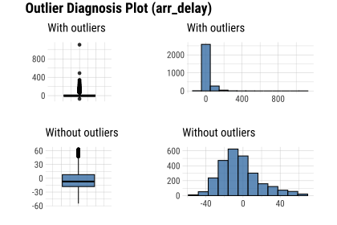

```r
flights %>%
  plot_outlier(arr_delay)
```

The following example uses `diagnose_outlier()`, `plot_outlier()`, and `dplyr` packages to visualize all numerical variables with an outlier ratio of 5% or higher.

```r
flights %>%
  plot_outlier(diagnose_outlier(flights) %>%
                 filter(outliers_ratio >= 5) %>%
                 select(variables) %>%
                 unlist())
```

[output not shown]

Analysts should look at the visualization results to decide whether to remove or replace outliers. Sometimes, you should consider removing variables with outliers from the data analysis model.

Looking at the visualization results, `arr_delay` shows that the observed values without outliers are similar to the normal distribution. In the case of a linear model, we might consider removing or imputing outliers.

### Visualization for missing values

It is essential to look at the missing values of individual variables, but it is also important to look at the relationship between the variables, including the missing values.

dlookr provides a visualization tool that looks at the relationship of variables, including missing values.

#### visualize pareto chart using `plot_na_pareto()`

`plot_na_pareto()` draws a Pareto chart by collecting variables, including missing values.

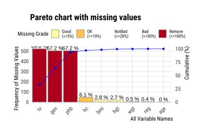

```r
mice::boys %>%
  plot_na_pareto(col = "blue")
```

```r
mice::boys %>%
  plot_na_pareto(only_na = TRUE, main = "Pareto Chart for mice::boys")
```

```r
mice::boys %>%
  plot_na_pareto(grade = list(High = 0.1, Middle = 0.6, Low = 1), relative = TRUE)
```

If the `plot` argument is set to FALSE, information about missing values is returned instead of plotting.

```r
plot_na_pareto(mice::boys, only_na = TRUE, plot = FALSE)
```

#### visualize combination chart using `plot_na_hclust()`

It is essential to look at the relationship between variables, including missing values. `plot_na_hclust()` visualizes the relationship of variables that contain missing values. This function rearranges the positions of variables using hierarchical clustering. Then, the expression of the missing value is visualized by grouping similar variables.

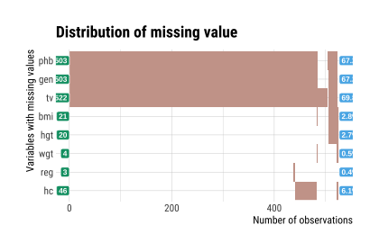

```r
mice::boys %>%
  plot_na_hclust(main = "Distribution of missing value")
```

#### visualize combination chart using `plot_na_intersect()`

`plot_na_intersect()` visualizes the combinations of missing values across cases.

The visualization consists of four parts. The bottom left, which is the most basic, visualizes the case of cross(intersection)-combination. The x-axis is the variable including the missing value, and the y-axis represents the case of a combination of variables. And on the marginal of the two axes, the frequency of the case is expressed as a bar graph. Finally, the visualization at the top right expresses the number of variables, including missing values in the data set, and the number of observations, including missing values and complete cases.

This example visualizes the combination of variables that include missing values.

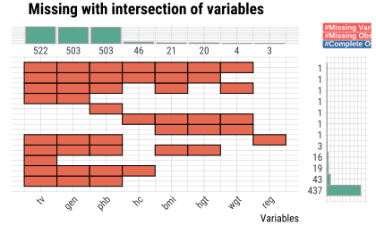

```r
mice::boys %>%
  plot_na_intersect()
```

If the `n_vars` argument is used, only the top `n` variables containing many missing values are visualized.

```r
mice::boys %>%
  plot_na_intersect(n_vars = 5)
```

If you use the `n_intersacts` argument, only the top n numbers of variable combinations(intersection), including missing values, are visualized. Suppose you want to visualize the combination variables, that includes missing values and complete cases. You just add only_na = FALSE.

```r
mice::boys %>%
  plot_na_intersect(only_na = FALSE, n_intersacts = 7)
```

## Automated report

dlookr provides two automated data diagnostic reports:

- Web page-based dynamic reports can perform in-depth analysis through visualization and statistical tables.
- Static reports generated as pdf files or html files can be archived as output of data analysis.

### Create a diagnostic report using `diagnose_web_report()`

`diagnose_web_report()` creates a dynamic report for objects inherited from data.frame(`tbl_df`, `tbl`, etc) or data.frame.

#### Contents of dynamic web report

The contents of the report are as follows.:

- Overview
  - Data Structures
    - Data Structures
    - Data Types
    - Job Information
  - Warnings
  - Variables
- Missing Values
  - List of Missing Values
  - Visualization
- Unique Values
  - Categorical Variables
  - Numerical Variables
- Outliers
- Samples
  - Duplicated
  - Heads
  - Tails

#### Some arguments for dynamic web report

diagnose_web_report() generates various reports with the following arguments.

- output_file
  - name of the generated file.
- output_dir
  - name of the directory to generate report file.
- title
  - title of the report.
- subtitle
  - subtitle of the report.
- author
  - author of the report.
- title_color
  - color of title.
- thres_uniq_cat
  - threshold to use for “Unique Values - Categorical Variables”.
- thres_uniq_num
  - threshold to use for “Unique Values - Numerical Variables”.
- logo_img
  - name of the logo image file on the top left.
- create_date
  - The date on which the report is generated.
- theme
  - name of theme for report. Support “orange” and “blue”.
- sample_percent
  - Sample percent of data for performing Diagnosis.

The following script creates a quality diagnosis report for the `tbl_df` class object, `flights`.

```r
flights %>%
  diagnose_web_report(subtitle = "flights", output_dir = "./",
                      output_file = "Diagn.html", theme = "blue")
```

#### Screenshot of dynamic report

- The part of the report is shown in the following figure.:

[figure not shown]

The part of the report

- The dynamic contents of the report are shown in the following figure.:

[figure not shown]

The dynamic contents of the report

### Create a diagnostic report using `diagnose_paged_report()`

`diagnose_paged_report()` create static report for object inherited from data.frame(`tbl_df`, `tbl`, etc) or data.frame.

#### Contents of static paged report

The contents of the report are as follows.:

- Overview
  - Data Structures
  - Job Information
  - Warnings
  - Variables
- Missing Values
  - List of Missing Values
  - Visualization
- Unique Values
  - Categorical Variables
  - Numerical Variables
- Categorical Variable Diagnosis
  - Top Ranks
- Numerical Variable Diagnosis
  - Distribution
    - Zero Values
    - Minus Values
  - Outliers
    - List of Outliers
    - Individual Outliers

#### Some arguments for static paged report

diagnose_paged_report() generates various reports with the following arguments.

- output_format
  - report output type. Choose either “pdf” or “html”.
- output_file
  - name of the generated file.
- output_dir
  - name of the directory to generate report file.
- title
  - title of the report.
- subtitle
  - subtitle of the report.
- abstract_title
  - abstract of the report
- author
  - author of the report.
- title_color
  - color of title.
- subtitle_color
  - color of subtitle.
- thres_uniq_cat
  - threshold to use for “Unique Values - Categorical Variables”.
- thres_uniq_num
  - threshold to use for “Unique Values - Numerical Variables”.
- flag_content_zero
  - whether to output “Zero Values” information.
- flag_content_minus
  - whether to output “Minus Values” information.
- flag_content_missing
  - whether to output “Missing Value” information.
- logo_img
  - name of the logo image file on the top left.
- cover_img
  - name of cover image file on center.
- create_date
  - The date on which the report is generated.
- theme
  - name of the theme for the report. Support “orange” and “blue”.
- sample_percent
  - Sample percent of data for performing Diagnosis.

The following script creates a quality diagnosis report for the `tbl_df` class object, `flights`.

```r
flights %>%
  diagnose_paged_report(subtitle = "flights", output_dir = "./",
                        output_file = "Diagn.pdf", theme = "blue")
```

#### Screenshot of static report

- The cover of the report is shown in the following figure.:

[figure not shown]

The part of the report

- The contents of the report are shown in the following figure.:

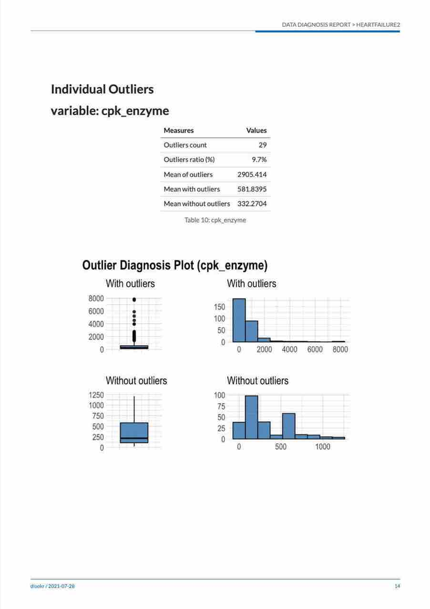

The dynamic contents of the report

## Diagnosing tables in DBMS

The DBMS table diagnostic function supports In-database mode that performs SQL operations on the DBMS side. If the data size is large, using In-database mode is faster.

It isn’t easy to obtain anomalies or to implement the sampling-based algorithm in SQL of DBMS. So, some functions do not yet support In-database mode. In this case, it is performed in In-memory mode in which table data is brought to the R side and calculated. In this case, if the data size is large, the execution speed may be slow. It supports the collect_size argument, allowing you to import the specified number of data samples into R.

- In-database support functions
  - `diagonse()`
  - `diagnose_category()`
- In-database not support functions
  - `diagnose_numeric()`
  - `diagnose_outlier()`
  - `plot_outlier()`
  - `diagnose_web_report()`
  - `diagnose_paged_report()`

### Preparing table data

Copy the `carseats` data frame to the SQLite DBMS and create it as a table named `TB_CARSEATS`. Mysql/MariaDB, PostgreSQL, Oracle DBMS, and other DBMS are also available for your environment.

```r
library(dplyr)

carseats <- Carseats
carseats[sample(seq(NROW(carseats)), 20), "Income"] <- NA
carseats[sample(seq(NROW(carseats)), 5), "Urban"] <- NA

# connect DBMS
con_sqlite <- DBI::dbConnect(RSQLite::SQLite(), ":memory:")

# copy carseats to the DBMS with a table named TB_CARSEATS
copy_to(con_sqlite, carseats, name = "TB_CARSEATS", overwrite = TRUE)
```

### Diagnose data quality of variables in the DBMS

Use `dplyr::tbl()` to create a tbl_dbi object, then use it as a data frame object. The data argument of all diagnose functions is specified as a tbl_dbi object instead of a data frame object.

```r
# Diagnosis of all columns
con_sqlite %>%
  tbl("TB_CARSEATS") %>%
  diagnose()

# Positions values select columns, and In-memory mode
con_sqlite %>%
  tbl("TB_CARSEATS") %>%
  diagnose(1, 3, 8, in_database = FALSE)

# Positions values select columns, and In-memory mode and collect size is 200
con_sqlite %>%
  tbl("TB_CARSEATS") %>%
  diagnose(-8, -9, -10, in_database = FALSE, collect_size = 200)
```

### Diagnose data quality of categorical variables in the DBMS

```r
# Positions values select variables, and In-memory mode and collect size is 200
con_sqlite %>%
  tbl("TB_CARSEATS") %>%
  diagnose_category(7, in_database = FALSE, collect_size = 200)

# Positions values select variables
con_sqlite %>%
  tbl("TB_CARSEATS") %>%
  diagnose_category(-7)
```

### Diagnose data quality of numerical variables in the DBMS

```r
# Diagnosis of all numerical variables
con_sqlite %>%
  tbl("TB_CARSEATS") %>%
  diagnose_numeric()

# Positive values select variables, and In-memory mode and collect size is 200
con_sqlite %>%
  tbl("TB_CARSEATS") %>%
  diagnose_numeric(Sales, Income, collect_size = 200)
```

### Diagnose outlier of numerical variables in the DBMS

```r
con_sqlite %>%
  tbl("TB_CARSEATS") %>%
  diagnose_outlier()  %>%
  filter(outliers_ratio > 1)
```

### Plot outlier information of numerical data diagnosis in the DBMS

```r
# Visualization of numerical variables with a ratio of
# outliers greater than 1%
# the result is same as a data.frame, but not display here. reference above in document.
con_sqlite %>%
  tbl("TB_CARSEATS") %>%
  plot_outlier(con_sqlite %>%
                 tbl("TB_CARSEATS") %>%
                 diagnose_outlier() %>%
                 filter(outliers_ratio > 1) %>%
                 select(variables) %>%
                 pull())
```

### Reporting the information of data diagnosis for table of thr DBMS

The following shows several examples of creating a data diagnosis report for a DBMS table.

Using the `collect_size` argument, you can perform data diagnosis with the corresponding number of sample data. If the number of data is huge, use `collect_size`.

```r
# create web report file.
con_sqlite %>%
  tbl("TB_CARSEATS") %>%
  diagnose_web_report()

# create pdf file. file name is Diagn.pdf, and collect size is 350
con_sqlite %>%
  tbl("TB_CARSEATS") %>%
  diagnose_paged_report(collect_size = 350, output_file = "Diagn.pdf")
```